### Bioinformatics Practical 3. Phylogentic inferences

**Aim of the practical**

**1)** To learn the principle of phylogenetic tree construction

**2)** Constructing a phylogenetic tree in R

# 1. Principle of tree construction

We will do a fun exercise before we do a real phylogenetic tree construction. Can you place these new organisms in order? And give your rationale for your placement of that organism in this tree.

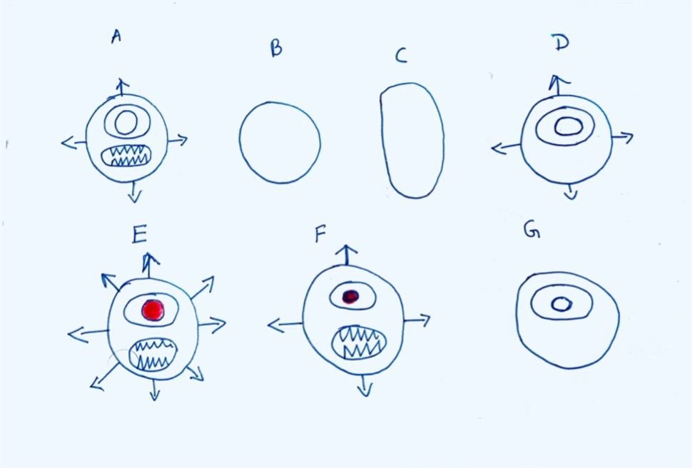

### Building a phylogenetic tree using some anatomical characters

Table below contains charatcters to make our tree. + indicates presence and 0 represents absence. This data taken from Principles of biology by Robert Bear (table from khan academy) with some modifications.

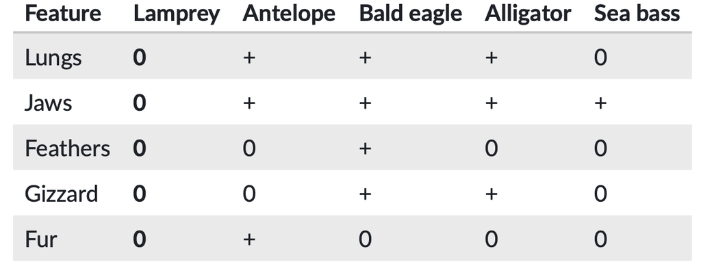

One important thing we should know from above table is what forms the ancestral trait, and which are derived traits. This is important to make a tree based on characters. An ancestral trait is what we think was present in the common ancestor of the species of interest. Also, if the trait is present only in the outgroup you can call it ancestral trait. A derived trait is a trait or character that appears somewhere on a lineage descended from common ancestor.

We will start building a tree now. Lampery lacks all the traits listed in the table. Hence we can assume that ancestors for these group of organisms lacked these listed traits. Presence of any or all features indicates they are derived traits.

1. Which of these characters are mostly shared by ? Jaws. Present in all except lampreys. So start off with drawing lamprey branching off from the rest.
2. What’s the next character shared by most of the species? Next, we can look for the derived trait shared by the next-largest group of organisms. This would be lungs, shared by the antelope, bald eagle, and alligator, but not by the sea bass. Based on this pattern, we can draw the lineage of the sea bass branching off, and we can place the appearance of lungs on the lineage leading to the antelope, bald eagle, and alligator.
3. Following the same pattern, we can now look for the derived trait shared by the next-largest number of organisms. That would be the gizzard, which is shared by the alligator and the bald eagle (and absent from the antelope). Based on this data, we can draw the antelope lineage branching off from the alligator and bald eagle lineage, and place the appearance of the gizzard on the latter.
4. What about our remaining traits of fur and feathers? These traits are derived, but they are not shared, since each is found only in a single species. Derived traits that aren’t shared by many don’t help us build a tree, but we can still place them on the tree in their most likely location. For feathers, this is on the lineage leading to the bald eagle (after divergence from the alligator). For fur, this is on the antelope lineage, after its divergence from the alligator and bald eagle.

# 2. Constructing a phylogenetic tree in R

Phylogentics in R needs various packages such as `msa` (Bonatesta et al), `bios2mds`,(Pele et al) and `phangorn` (Schliep et al). One benefit of using R functions to calculate the phylogentic tree is that you dont need some other software(s) which are many times OS dependent and hence, unpredictable.

## 1. Install or load R packages

Some of the packages (phangorn, tinytex, and bios2mds) can be directly downloadable from R studio “packages” tab. However, **msa package** needs to be downloaded using **Bioconductor**. Type “msa r package” in google and find relevant bioconductor package. Read relevant information about how to download msa.

```
#load packages
library(tinytex)
library(msa)
library(bios2mds)
library(phangorn)
system.file("tex", "texshade.sty", package="msa") # needed for Latex/Texshade related function to work
```

## 2. Alignment of nucleotide sequences

### 2.1 read sequences in fasta format into msa

```
mysequencefile <- readDNAStringSet("phylogenetics_tree.fasta", format = "fasta")
```

### 2.2 run multiple alignemnt analysis using `muscle` program

This following step can lot of time, depending on number of sequences and length. Here it will go fast.

```
alignmuscle  <- msa(mysequencefile,method = "Muscle")
```

The following step is optional. The frame of reference for aligned sequences is static (and already defined), so manipulation of these objects is confined to be non-destructive. This means that the aligned sequence objects contain properties to mask ranges of rows and columns on the original sequence. These masks are then respected by methods that manipulate and display the objects (such as tree building algorithm), allowing the user to remove or keep columns and rows without invalidating the original alignment. Follwing function will do this. We will try to mask first 10 bases of alignment.

#### mask sequences

```
myMaskedAlignment <- alignmuscle #rename object  alignmuscle
colM <- IRanges(start=1, end=10) #select ranges to mask
colmask(myMaskedAlignment) <- colM #rename object colM
myMaskedAlignment # view object with masked sequences
```

If you want to see alignments look pretty with different colours for different bases as in some GUI based programs. We try one simple script, there are lot of options in `msaPrettyPrint` function.

```
msaPrettyPrint(alignmuscle, output="pdf", y=c(1, 633),
               subset=c(1:6), showNames="none", showLogo="top",
               logoColors="rasmol", shadingMode="similar",
               showLegend=FALSE, askForOverwrite=FALSE)
```

You might see the following error message:

> **Error in texi2dvi(texfile, quiet = !verbose, pdf = identical(output, “pdf”),**

> unable to run pdflatex

If this happened, it means that your computer is missing the Latex program, that is responsible for generating the pdf image with the pretty alignment. To solve this you will need to follow the steps below:

#### Download and install the Latex program from this [link](https://www.latex-project.org/get/):

At the bottom of the page, choose the version that suits your operating system:

1. *MacTeX* for Macs
2. *MikTex* for Windows
3. *LinuxTex dist* for Linux

Click the link to the version you need to install, download it and install it. After installing your version of Latex (MikTex, MacTex or LinuxTex), search for it using your Mac `finder` or the windows search bar and **open it**.

You will be prompted with a text editor like window. This is your Latex. Go back to R and run the following command:

```
msaPrettyPrint(alignmuscle, output="tex", y=c(1, 633),
               subset=c(1:6), showNames="none", showLogo="top",
               logoColors="rasmol", shadingMode="similar",
               showLegend=FALSE, askForOverwrite=FALSE)
```

Observe that the value inside the parameter `output=` was changed from **pdf** to **tex**, if this command ran without problems, you generated a text file called `alignmuscle.tex`. Open this file using your *Latex* program and hit run. After doing these steps, you should be prompted with a question about installing the package `TeXshade` to generate the pretty alignment PDF. Just accept the installation steps and you will see your pretty alignment.

Having done all of that, your previous `msaPrettyPrint()`, with the parameter `output="pdf"` will likely work. Maybe you need to close your R studio and open it again… If nothing of that works, you won’t have a pretty alignment to show for now :/

Once you are done with alignment, next step is making the phylogenetic tree. This follwing function converts a multiple sequence alignment object to formats used in other sequence analysis packages. Benefit of this is that you can directly proceed to other packages without reading the input again.

```
alignmentfish <- msaConvert(alignmuscle, type= "phangorn::phyDat")
```

optional: you may want to write alignment file to hard disk use following command and use it someother non R based programs.

```
export.fasta(alignmuscle2, outfile = "test_alignment.fa", ncol = 60, open = "w")
```

```
alignmentfish1 <-read.phyDat(alignmentfish, type = "dna", format = "fasta")
```

Now we will try to do some phylogenetic trees based on different methods.

## 3. Phylogenetic tree construction

### 3.1 Distance based phylogenetic tree construction

First calculate a distance matrix

```
dm <- dist.ml(alignmentfish)  #calculate distance matrix using dist.ml from phangorn
```

Plot trees using generic function.

[output not shown]

To get statistical significance values for branch split you need to perform bootstrapping.

### 3.1a Run bootstrapping

Bootstrapping is a test or metric that uses random sampling with replacement and falls under the broader class of resampling methods. It uses sampling with replacement to estimate the sampling distribution for the estimator (Ojha et al 2022). Basic idea is building same tree leaving out some portion of evidence and check if same clades appear even after leaving out some data

First we need to write a function

```
fun <- function(x) upgma(dist.ml(x)) ## function calculates distance first and then tree is calculated from alignment. function fun performs tree building on the input x using the upgma algorithm after calculating the pairwise distance between elements using dist.ml.
```

Then need to calculate boot strap values through bootstrap.phyDat function from phangron.

```
bs_upgma <- bootstrap.phyDat(alignmentfish, fun)
```

plot the bootstrap values on tree branches

```
plotBS(treeUPGMA, bs_upgma, main="UPGMA") #plot bootstrap values
```

### 3.2 Parsimony based trees

Now we will caluclate parsimony score, which is the minimum number of changes ncecessary to describe the data for a given tree type.

```
parsimony(treeUPGMA, alignmentfish)

parsimony(treeNJ, alignmentfish) #parsimony returns the parsimony score of a tree
```

#### Calculate parsimony tree

```
treeRatchet  <- pratchet(alignmentfish, trace = 0, minit=100, maxit = 1000) ##lower number of iterations for the example (to run less than 5 seconds), keep default values (maxit, minit, k) or increase them for real life analyses.
parsimony(treeRatchet, alignmentfish)

#assign edge length (number of substitutions)
treeRatchet  <- acctran(treeRatchet,alignmentfish)

#remove edges of length 0
treeRatchet <- di2multi(treeRatchet)

#### remove duplicate trees
if(inherits(treeRatchet, "multiPhylo")){
  treeRatchet <- unique(treeRatchet)
}
```

##### Root tree with option midpoint, a method to root the tree.

Midpoint rooting method calculates tip to tip distances and then places the root point halfway between two longest tips.It assuen rate of evolution is constant (equal substitution rates) in the tree. It is an ideal method if you lack a proper outgtoup (absence or lack of knowledge), like in virus phylogenomics.

```
plotBS(midpoint(treeRatchet), type="phylogram")
add.scale.bar()
```

Outgroup rooting method assumes that one or more of the tax aee divergent from the rest of the ingroup tax. The btanch linking the ingroup and outgroup becoems the starting point and all the evolutionary changes defined from here. One important thing is that you need to have priori knowledge about the outgroup, when it is confusing,people either choose close or very distant species as ourgroup. if you want to root a tree with specific species (need prior knowledge) then you need to use functions from package àpe`.

```
rooted_tree <- root(treeRatchet, outgroup = "Esox lucius", resolve.root = TRUE,
                       edgelabel = TRUE)
add.scale.bar()
```

### 3.3 Maximum Likelihood

#### compare different nucleotide substitution models

```
mt <- modelTest(alignmentfish, control=pml.control(trace=0))
```

As a first step, we will try to find the best fitting substition model. For this we use the function `modelTest` to compare different nucleotide or protein models with the AIC, AICc or BIC,

```
fit <- as.pml(mt, "BIC") #choose best model based on BIC criteria
```

#### make a ml tree

Or let the program to choose best model based on the criteria and pass it to tree building algorithm.

```
fit_mt <- pml_bb(mt, control = pml.control(trace = 0))
fit_mt

bs <- bootstrap.pml(fit_mt, bs=100, optNni=TRUE, control = pml.control(trace = 0)) #do a standard bootstrapping

plotBS(midpoint(fit_mt$tree), bs, p = 50, type="p", main="Standard bootstrap") # plot trees with midpoint rooting

tree_stdbs <- plotBS(midpoint(fit_mt$tree), bs, p = 50, type="n", main="Standard bootstrap")
##assigning standard bootstrap values to our tree; this is the default method
```

#### exporting trees tree with standard bootstrap values in `newick` format.

```
write.tree(tree_stdbs, "fish.tree")
```

Extra information: ’Beauti’fication of phylogenetic trees can be done using `ggplot`and its associated package called `ggtree` can be used to make trees more beautiful.

Reference: some scripts are taken from tutorial: estimating phylogenetic trees with phangorn